# FA Home Work 1

Ilya Fominykh

09 06 2020

Скачаем и подключим библиотеки

```r
library(haven)
library(dplyr)
library(foreign)
library(psych)
library(GGally)
library(GPArotation)
library(nFactors)
library(lavaan)
library(semTools)
library(semPlot)
```

**Задание 0.**Выбрать любую страну, которая Вам кажется любопытной для анализа в контексте поставленной содержательной задачи. Поясните свой выбор.

Так как наша содержательная задача – “выделить разные понимания-трактовки демократии”, а в контексте оригинального исследования ( Welzel & Kirsch 2017) указывалось, что эти трактовки свойственны для режимов, находящихся между автократиями и демократиями, нам необоходимо выбрать любую из стран, входящих в число semi-autocracies, или полуавтократий. В этом контексте, для нас хорошо подойдет кейс России, которую в сложившейся исследователькой традиции принято относить как раз к таким режимам, сочетающим как элементы демократии, так и элементы автократии без решающего превалирования одних над другими.

Теперь, загрузим данные WVS6 Russia, А также удалим лишние данные, не имеющие отношения к блоку вопросов по трактовке демократии (переменные V131 – V139):

```r
WVS <- read_dta(file.choose())
WVS_dem <- dplyr::select(WVS, V131, V132, V133, V134, V135, V136, V137, V138, V139)
```

После этого, удалим ответы “не знаю”, а также отсутствующие ответы. В оригинальной кодировке им соответсвуют значения -1 и -2. Также удалим значения -5, в т.ч. не несущие для нас содержательного смысла.

```r
WVS_dem_clean <- WVS_dem
WVS_dem_clean[WVS_dem_clean == -2] <- NA
WVS_dem_clean[WVS_dem_clean == -1] <- NA
WVS_dem_clean[WVS_dem_clean == -5] <- NA
WVS_dem_cl <- na.omit(WVS_dem_clean)
```

**Задание 1.** Запишите вид модели разведывательного ФА в данном случае. Дайте максимально полную интерпретацию полученным результатам. Сколько латентных факторов разумно выделить? Насколько полученные результаты согласуются с Вашими исходными предположениями? Обсудите возможные решения. Проинтерпретируйте меры качества решения.

В первую очередь, проверим данные на применимость ФА

```r
corr <- cor(WVS_dem_cl)
corr
```

```
##            V131         V132        V133        V134        V135        V136
## V131 1.00000000  0.012798450  0.41925585  0.47025008  0.04618535  0.42511941
## V132 0.01279845  1.000000000 -0.20463602 -0.10269541  0.28071999 -0.20419245
## V133 0.41925585 -0.204636023  1.00000000  0.58868671 -0.06978884  0.64901532
## V134 0.47025008 -0.102695411  0.58868671  1.00000000  0.04155845  0.55753490
## V135 0.04618535  0.280719988 -0.06978884  0.04155845  1.00000000 -0.04204673
## V136 0.42511941 -0.204192453  0.64901532  0.55753490 -0.04204673  1.00000000
## V137 0.42990848 -0.007354165  0.41393705  0.54002696  0.09391385  0.46300421
## V138 0.29964750  0.098303351  0.21018376  0.28177099  0.16377404  0.24477239
## V139 0.36925463 -0.177414591  0.54663128  0.53774710 -0.05683570  0.57383397
##              V137       V138       V139
## V131  0.429908476 0.29964750  0.3692546
## V132 -0.007354165 0.09830335 -0.1774146
## V133  0.413937046 0.21018376  0.5466313
## V134  0.540026957 0.28177099  0.5377471
## V135  0.093913847 0.16377404 -0.0568357
## V136  0.463004211 0.24477239  0.5738340
## V137  1.000000000 0.39874793  0.4728944
## V138  0.398747934 1.00000000  0.2992055
## V139  0.472894410 0.29920545  1.0000000
```

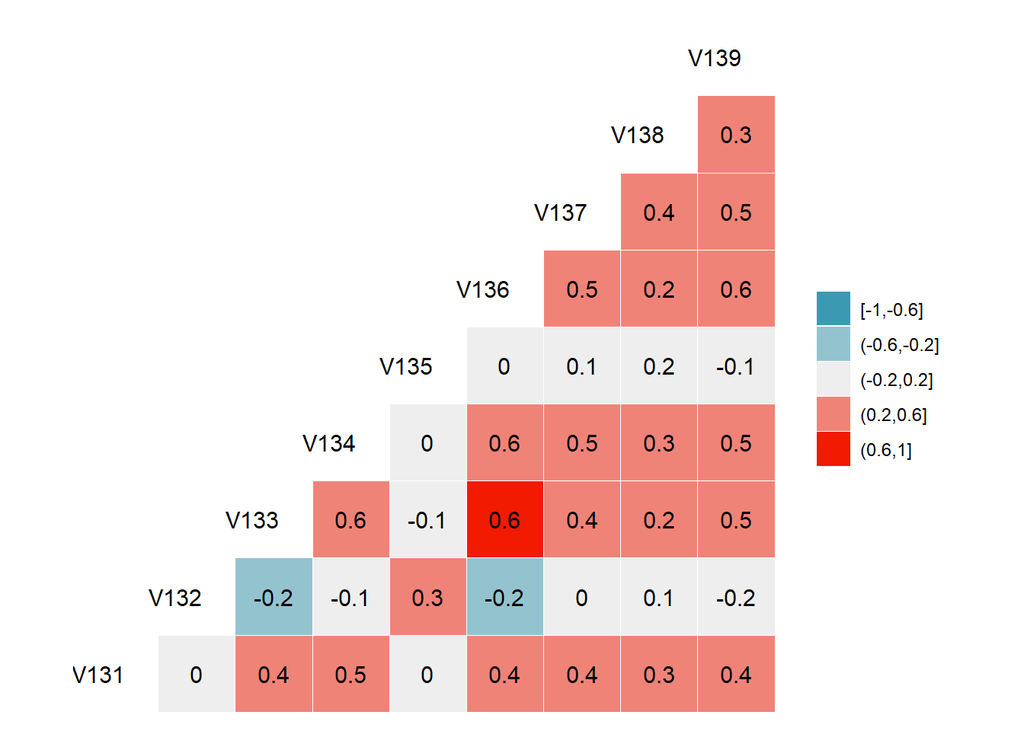

```r
ggcorr(WVS_dem_cl, nbreaks = 5, label = T, size = 4, hjust = 0.9)
```

Как мы видим, корреляции между рядом показателей принимают значение от -0.2 до 0.2. Но большинство корреляций находится в радиусе от 0.3 до 0.6. В общем виде, это не дает нам однозначного ответа, будет ли применение ФО продуктивно на этих данных, но и не говорит об обратном. Резюмируя, данные скорее подходят, чем не подходят для реализации ФО, требуется дополнительная проверка.

```r
KMO(WVS_dem_cl)
```

```
## Kaiser-Meyer-Olkin factor adequacy
## Call: KMO(r = WVS_dem_cl)
## Overall MSA =  0.87
## MSA for each item =
## V131 V132 V133 V134 V135 V136 V137 V138 V139
## 0.91 0.67 0.86 0.88 0.59 0.87 0.88 0.84 0.90
```

Общий результат = 0.87. Такой результат считается довольно хорошим и указывает на то, что применение ФА на указанной выборке допустимо. Так, значения критерия Кайзера-Майера-Олкина находятся выше средних значений: недопустимым применение ФА cчитается, если общий результат по критерию менее 0.5.

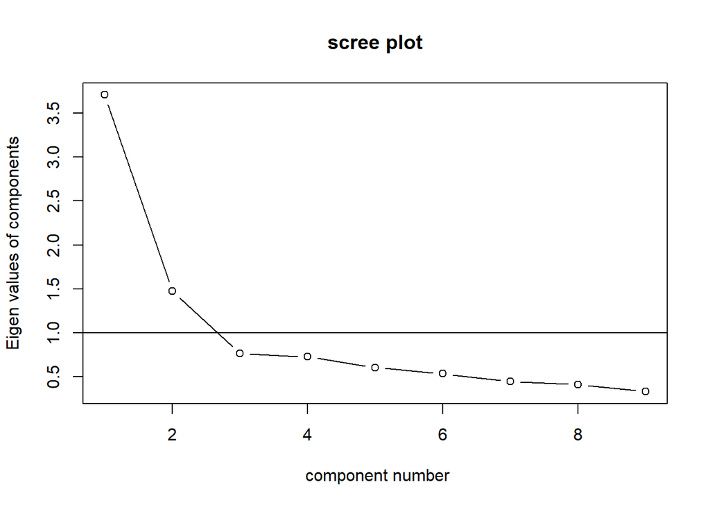

```r
VSS.scree(corr)
```

На основе графика Каменистой осыпи видно, что скорость изменения собственных значений компонет уменьшается на третьей компоненте. Прямая линия на единице позволяет одновременно применить критерий Кайзера: он указывает на то, что только две компоненты принимают значение более 1. Таким образом, оба критерия указывают на то, что нам стоит извлекать два фактора.

Дополнительно, обратимся к параллельному анализу, чтобы определить, сколько факторов нам необходимо извлекать.

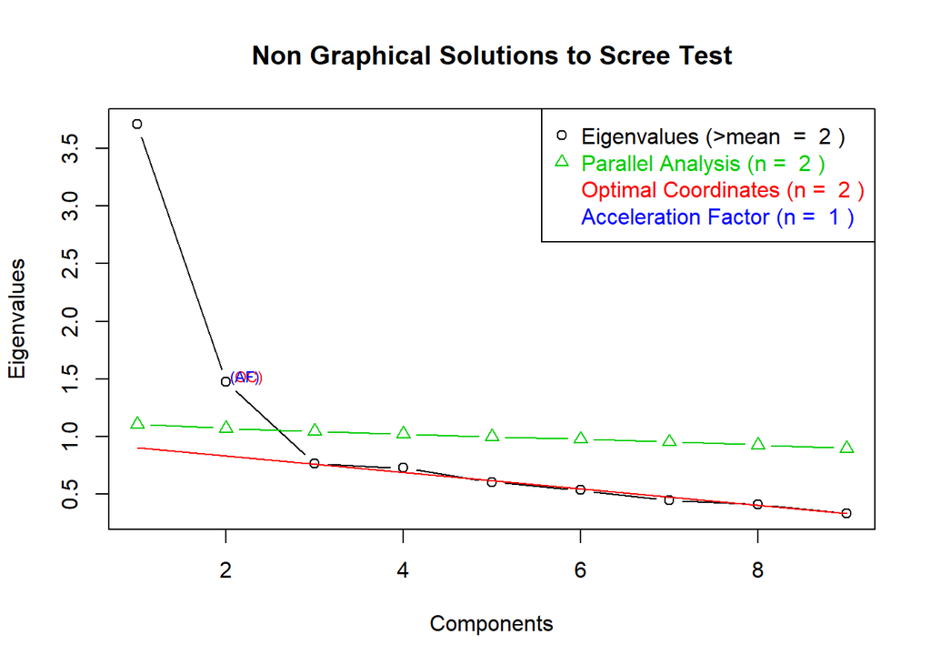

```r
eigen <- eigen(cor(WVS_dem_cl))
p <- parallel(var = ncol(WVS_dem_cl), subject = nrow(WVS_dem_cl), rep = 1000)$eigen$mevpea
screeplot <- nScree(x=eigen$values, aparallel = p)
plotnScree(screeplot)
```

Как мы видим, значения по исходной выборке превышают те значения, которые мы получили по параллельному анализу в двух случаях. Так, подтверждающий анализ подтверждает те выводы, к которым мы пришли ранее после применения критерия Кайзера и критерия Кеттела. Поэтому, резюмируя все использованные методы, для последующего анализа нам **нужно извлечь два фактора.**

Когда мы узнали количество факторов, мы можем реализовать разведывательный факторный анализ. Для начала, сделаем ортогональное вращение

```r
efa1 <- fa(r = corr, nfactors = 2, fm = "pa", rotate = "varimax") # pa - principal factor FA
efa1
```

```
## Factor Analysis using method =  pa
## Call: fa(r = corr, nfactors = 2, rotate = "varimax", fm = "pa")
## Standardized loadings (pattern matrix) based upon correlation matrix
##        PA1   PA2   h2   u2 com
## V131  0.59  0.12 0.37 0.63 1.1
## V132 -0.13  0.54 0.31 0.69 1.1
## V133  0.74 -0.25 0.61 0.39 1.2
## V134  0.76 -0.01 0.58 0.42 1.0
## V135  0.04  0.47 0.22 0.78 1.0
## V136  0.76 -0.21 0.62 0.38 1.2
## V137  0.69  0.20 0.51 0.49 1.2
## V138  0.43  0.32 0.29 0.71 1.9
## V139  0.71 -0.14 0.52 0.48 1.1
##
##                        PA1  PA2
## SS loadings           3.23 0.79
## Proportion Var        0.36 0.09
## Cumulative Var        0.36 0.45
## Proportion Explained  0.80 0.20
## Cumulative Proportion 0.80 1.00
##
## Mean item complexity =  1.2
## Test of the hypothesis that 2 factors are sufficient.
##
## The degrees of freedom for the null model are  36  and the objective function was  2.82
## The degrees of freedom for the model are 19  and the objective function was  0.07
##
## The root mean square of the residuals (RMSR) is  0.02
## The df corrected root mean square of the residuals is  0.03
##
## Fit based upon off diagonal values = 1
## Measures of factor score adequacy
##                                                    PA1  PA2
## Correlation of (regression) scores with factors   0.94 0.74
## Multiple R square of scores with factors          0.87 0.55
## Minimum correlation of possible factor scores     0.75 0.10
```

Сумма квадратов нагрузок для каждого из факторов (SS loadings) содержательно показывает, какую часть вариации объясняет этот фактор. Так, например, 3.23 - это часть общей вариации, которую объясняет первый фактор. пропорционально объясненная доля вариации (proportion var) рассчитывается на основе этого значения, она показывает какую часть от вариации в % отношении объясняет тот или иной фактор. Так, например, 0.36 - это доля общей вариации, которую объясняет первый фактор.

также, узнав коэффициенты, мы можем записать модель, специфичную для РФА в нашем случае:

V_i=PA1_ixF_1+PA2_ixF_2+e

где V - переменная из исходного датасета, PA - коэффициенты при факторе, или факторные нагрузки (их можно узнать из выдачи выше для каждой конкретной переменной и каждого конкретного фактора), F - факторы модели (ранее мы указали, почему извлекаются 2 фактора), а e - ошибка.

Для содержательной интерпретации факторов,Повторим содержательное значение переменных:

V131 “отношение к налогам в пользу бедных” V132 “важность мнения религиозных лидеров” V133 “отношение к свободным выборам” V134 “пособие для безработных” V135 “Армия берет власть, если правительство некомпетентно” V136 “отношение к гражданским правам” V137 “обеспечение государством равенства доходов” V138 “люди подчиняются правителям” V139 “у мужчин и женщин должны быть равные права”

А также выгрузим только значимые факторные нагрузки:

```r
print(efa1$loadings, cutoff=0.3)
```

```
##
## Loadings:
##      PA1    PA2
## V131  0.592
## V132         0.539
## V133  0.739
## V134  0.764
## V135         0.467
## V136  0.758
## V137  0.686
## V138  0.430  0.324
## V139  0.709
##
##                  PA1   PA2
## SS loadings    3.229 0.793
## Proportion Var 0.359 0.088
## Cumulative Var 0.359 0.447
```

Содержательная интерпретация второго фактора технически сложнее, так как он объясняет сравнительно небольшую долю общей вариации. Тем не менее, мы видим, что в него с наибольшими факторными нагрузками входят переменные v132, v135 и v138, которые можно связать с наличием сильной и авторитетной лидерской фигуры(например, в лице армии или церкви). Условно, возможна интерпретация как “важность наличия у лидера опоры для власти”. Эта опора может выражаться как в уважении и авторитете, так и в военной мощи и лидерской готовности взять власть, реализовывать свои решения.

В последнюю очередь, реализуем РФА, но не с ортогональным, а с косоугольным вращением.

```r
efa2<- fa(r = corr, nfactors = 2, fm = "pa", rotate = "oblimin")
efa2
```

```
## Factor Analysis using method =  pa
## Call: fa(r = corr, nfactors = 2, rotate = "oblimin", fm = "pa")
## Standardized loadings (pattern matrix) based upon correlation matrix
##        PA1   PA2   h2   u2 com
## V131  0.57  0.18 0.37 0.63 1.2
## V132 -0.19  0.52 0.31 0.69 1.3
## V133  0.76 -0.17 0.61 0.39 1.1
## V134  0.76  0.07 0.58 0.42 1.0
## V135 -0.02  0.47 0.22 0.78 1.0
## V136  0.78 -0.13 0.62 0.38 1.1
## V137  0.66  0.27 0.51 0.49 1.3
## V138  0.39  0.37 0.29 0.71 2.0
## V139  0.72 -0.06 0.52 0.48 1.0
##
##                        PA1  PA2
## SS loadings           3.23 0.79
## Proportion Var        0.36 0.09
## Cumulative Var        0.36 0.45
## Proportion Explained  0.80 0.20
## Cumulative Proportion 0.80 1.00
##
##  With factor correlations of
##      PA1  PA2
## PA1 1.00 0.01
## PA2 0.01 1.00
##
## Mean item complexity =  1.2
## Test of the hypothesis that 2 factors are sufficient.
##
## The degrees of freedom for the null model are  36  and the objective function was  2.82
## The degrees of freedom for the model are 19  and the objective function was  0.07
##
## The root mean square of the residuals (RMSR) is  0.02
## The df corrected root mean square of the residuals is  0.03
##
## Fit based upon off diagonal values = 1
## Measures of factor score adequacy
##                                                    PA1  PA2
## Correlation of (regression) scores with factors   0.94 0.74
## Multiple R square of scores with factors          0.88 0.54
## Minimum correlation of possible factor scores     0.76 0.09
```

Как мы видим, в результате факторные нагрузки стали более выраженными.

**Задание 2.** Сформулируйте гипотезы относительно уточнения спецификации модели, в частности, на основе разведывательного факторного анализа. Реализуйте конфирматорный факторный анализ на Ваших данных. Предложите максимально полную интерпретацию (факторные нагрузки, общности и специфичности), прокомментируйте меры качества, уточните модель (на основе EPC и/или модификационных индексов), представьте путевую диаграмму для итоговых результатов.

После РФА мы выяснили, сколько у нас дожно быть факторов, а также выдвинули имеющие эмпирические основания предположения об их качественном содержании. Это позволяет нам, учитывая и факторные нагрузки в РФА, выдвигать гипотезы по поводу того, что должны в себя включать факторы ПФА. Иными словами, опираясь на РФА, мы специфицируем модель ПФА.

Так как РФА основан на жестких допущениях (таких, как равенство Cor между факторами 0, отсутствию корреляции между специфичностями и ошибками, что неправдоподобно в контексте наших данных и ранее выделенного содержательного значения факторов), нам необходимо провести дополнительно ПФА.

```r
cfa1_1 <- 'equality =~ V131 + V133 + V134 + V136 + V137 + V139
power =~ V132 + V135 + V138'

model1 <- cfa(cfa1_1, WVS_dem_cl)
summary(model1, fit.measures = TRUE, standardized = TRUE)
```

```
## lavaan 0.6-6 ended normally after 54 iterations
##
##   Estimator                                         ML
##   Optimization method                           NLMINB
##   Number of free parameters                         19
##
##   Number of observations                          1849
##
## Model Test User Model:
##
##   Test statistic                               749.094
##   Degrees of freedom                                26
##   P-value (Chi-square)                           0.000
##
## Model Test Baseline Model:
##
##   Test statistic                              5212.406
##   Degrees of freedom                                36
##   P-value                                        0.000
##
## User Model versus Baseline Model:
##
##   Comparative Fit Index (CFI)                    0.860
##   Tucker-Lewis Index (TLI)                       0.807
##
## Loglikelihood and Information Criteria:
##
##   Loglikelihood user model (H0)             -36775.227
##   Loglikelihood unrestricted model (H1)             NA
##
##   Akaike (AIC)                               73588.453
##   Bayesian (BIC)                             73693.379
##   Sample-size adjusted Bayesian (BIC)        73633.016
##
## Root Mean Square Error of Approximation:
##
##   RMSEA                                          0.123
##   90 Percent confidence interval - lower         0.115
##   90 Percent confidence interval - upper         0.130
##   P-value RMSEA <= 0.05                          0.000
```

[output cut: 28 more lines]

```
##     power            -0.022    0.056   -0.393    0.694   -0.014   -0.014
##
## Variances:
##                    Estimate  Std.Err  z-value  P(>|z|)   Std.lv  Std.all
##    .V131              4.879    0.173   28.157    0.000    4.879    0.674
##    .V133              2.288    0.097   23.519    0.000    2.288    0.407
##    .V134              2.427    0.102   23.755    0.000    2.427    0.416
##    .V136              2.038    0.088   23.081    0.000    2.038    0.393
##    .V137              3.976    0.146   27.310    0.000    3.976    0.601
##    .V139              2.614    0.103   25.488    0.000    2.614    0.489
##    .V132              5.436    0.325   16.707    0.000    5.436    0.828
##    .V135              4.357    0.913    4.773    0.000    4.357    0.537
##    .V138              6.940    0.248   27.934    0.000    6.940    0.944
##     equality          2.358    0.188   12.573    0.000    1.000    1.000
##     power             1.132    0.298    3.804    0.000    1.000    1.000
```

Мы видим, что у нас применялся ММП. Так, мы имеем возможность сравнить разные спецификации модели. Помимо этого, мы видим значение статистики хи-квадрат (test statistic), по которой мы можем проверить гипотезу о незначимости модели. Также в выдаче есть степени свободы (Degrees of freedom) - по ним мы можем идентифицировать модель: положительное кол-во степеней свободы свидетельствует о идентифицируемости модели, возможности сделать статистическую инференцию.

Но test statistic очень сильно зависит от размера выборки - если n велико, мы будем чаще отвергать H0. Чтобы учесть это, обратимся к критерию RMSEA - он делает поправку на размер выборки и кол-во параметров модели. Чем ниже его значения, тем лучше Если взять его границу как условно равную 0.05, то мы должны прийти к выводу, что качество нашей модели весьма низкое. К тем же выводам мы придем, если мы посмотрим на доверительные интервалы. Наш Pvalue невысок, а значит RMSEA не находится в пределе допустимых значений (мы отвергаем H0)

Обратимся также к индексам Такера-Льюиса и CFI. Эти индексы сравнимают нашу и базовую модель без совместной изменчивости. CFI уже приведен к шкале от 0 до 1. Чем ближе к 1 - тем выше качество модели. Пороговые значения ~ выше 0.9-0.95. В нашем случае, согласно обеим индексам, качество модели сравнительно низкое.

Индекс SRMR измеряет среднее отклонение наблюдаемых значений совариации от предсказанных моделью(т.е. то, насколько велики ошибки в модели). Пороговое значение - 0.08, наша модель, опять, превышает данное пороговое значение (0.124).

Как мы можем видеть, первые показатели каждого фактора (V131 AND V132) были выбраны как референтные. На основе их измеряется вариация каждого фактора. Первый столбец - нестандартизированное решение, посдледний - стандартизированное. Если нам надо понять сопоставимость результатов по подгруппам, нам нужно обращаться к нестандартизированным решениям. Но в нашем случае вопрос обстоит не так.

В нашем случае, Pvalue ковариации факторов очень велик, что указывает на её незначимость.

Теперь, мы можем визуализировать результаты:

```r
semPaths(model1, "std", rotation = 2,
           nodeLabels = c("V131",
                        "V133",
                        "V134",
                        "V136",
                        "V137",
                        "V139",
                        "V132",
                        "V135",
                        "V138",
                         "equality", "power"),
colFactor = 0, sizeMan = 10, sizeMan2 = 5, sizeLat = 10, edge.color = "red",
edge.label.cex = 1, esize = 1, mar = c(3,10,3,10))
```

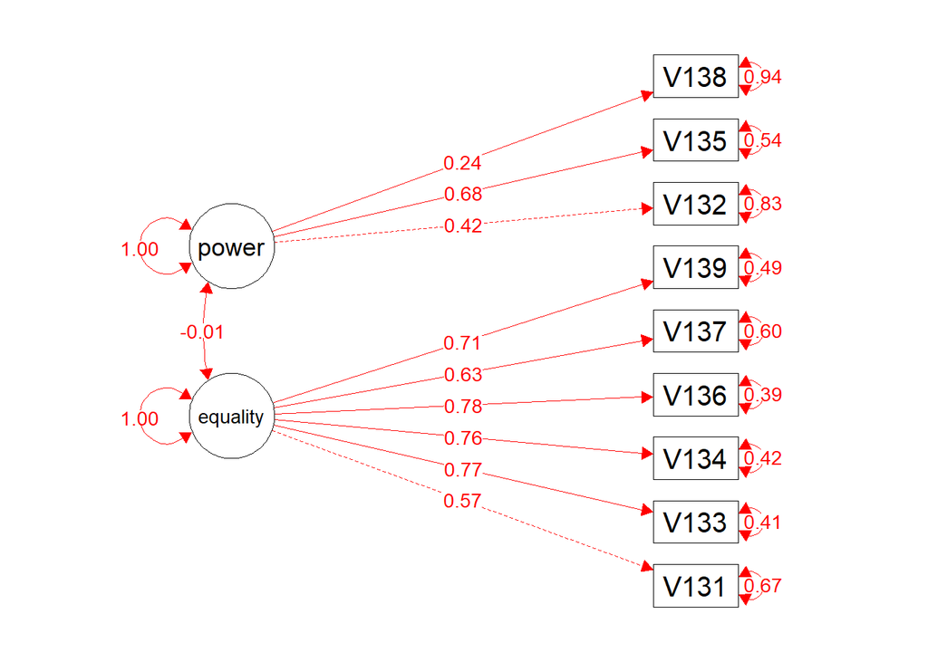

Стоит указать, что пунктирные линии соответствуют референтным показателям.

Покажем, как интерпретируются факторные нагрузки при стандартизированном решении (отражены в “стрелочках” графика). Начнем с Фактора “power” и переменной v138 (cодержательное значение факторов и переменных дано выше, в нашем случае оно соответствует 0.24). Во-первых, интерпретация факторной нагрузки возможна как корреляция между фактором и показателем. Вторая возможная интерпретация - возведение факторной нагрузки в квадрат, чтобы получить ту долю вариации показателя, которую объясняет фактор. В указанном случае, эта доля составит 0.06. (такую часть вариации V138 объясняет “power”, этот же показатель называется “общность”).В-третьих, возможна интерпретация, параллельная интерпретации коэффициентов в регрессионном анализе: при увеличении “power” на 1 стандартное отклонение, на 0.24 увеличивается стандартное отклонение V138 при прочих равных условиях. Все эти же интерпретации можно привести для любой другой факторной нагрузки модели. Вариации ошибок, отраженные красными круглыйми стрелочками - это “специфичности” (т.е. необъясненные фактором вариации ошибки) В нашем случае, специфичность V138 будет соответствовать значению 0.94. По той же логике, можно узнать специфичность любого из параметров.

Получив такие результаты, от нас потребуется уточнение модели.

```r
mepc <- modindices(model1, sort. = TRUE)
mepc
```

```
##         lhs op  rhs      mi      epc  sepc.lv sepc.all sepc.nox
## 24 equality =~ V138 264.255    0.715    1.098    0.405    0.405
## 64     V132 ~~ V135 264.190 -262.214 -262.214  -53.881  -53.881
## 60     V137 ~~ V138 100.536    1.300    1.300    0.248    0.248
## 22 equality =~ V132  78.890   -0.373   -0.573   -0.224   -0.224
## 66     V135 ~~ V138  78.885   49.353   49.353    8.976    8.976
## 29    power =~ V137  71.651    0.534    0.568    0.221    0.221
## 40     V133 ~~ V136  64.863    0.618    0.618    0.286    0.286
## 41     V133 ~~ V137  63.296   -0.708   -0.708   -0.235   -0.235
## 26    power =~ V133  38.998   -0.321   -0.342   -0.144   -0.144
## 47     V134 ~~ V137  38.549    0.565    0.565    0.182    0.182
## 46     V134 ~~ V136  37.770   -0.480   -0.480   -0.216   -0.216
## 54     V136 ~~ V132  29.204   -0.494   -0.494   -0.149   -0.149
## 38     V131 ~~ V138  28.686    0.760    0.760    0.131    0.131
## 34     V131 ~~ V137  27.265    0.595    0.595    0.135    0.135
```

[output cut: 31 more lines]

У нас не самое лучшее качество модели - поэтому мы обратимся к значениям модификационного индекса(mi),чтобы понять, что стоит внести в модель. Если бы качество модели было хорошим, мы бы обратили внимание на вклады (sepc.lv).

```r
cfa2 <- 'equality =~ V131 + V133 + V134 + V136 + V137 + V139
power =~ V132 + V135 + V138
equality =~ V138'
model2 <- cfa(cfa2, WVS_dem_cl)

summary(model2, fit.measures = TRUE, standardized = TRUE)
```

```
## lavaan 0.6-6 ended normally after 56 iterations
##
##   Estimator                                         ML
##   Optimization method                           NLMINB
##   Number of free parameters                         20
##
##   Number of observations                          1849
##
## Model Test User Model:
##
##   Test statistic                               429.113
##   Degrees of freedom                                25
##   P-value (Chi-square)                           0.000
##
## Model Test Baseline Model:
##
##   Test statistic                              5212.406
##   Degrees of freedom                                36
##   P-value                                        0.000
##
## User Model versus Baseline Model:
##
##   Comparative Fit Index (CFI)                    0.922
##   Tucker-Lewis Index (TLI)                       0.888
##
## Loglikelihood and Information Criteria:
##
##   Loglikelihood user model (H0)             -36615.236
##   Loglikelihood unrestricted model (H1)             NA
##
##   Akaike (AIC)                               73270.472
##   Bayesian (BIC)                             73380.920
##   Sample-size adjusted Bayesian (BIC)        73317.380
##
## Root Mean Square Error of Approximation:
##
##   RMSEA                                          0.094
##   90 Percent confidence interval - lower         0.086
##   90 Percent confidence interval - upper         0.101
##   P-value RMSEA <= 0.05                          0.000
```

[output cut: 30 more lines]

```
##     power            -0.595    0.098   -6.076    0.000   -0.226   -0.226
##
## Variances:
##                    Estimate  Std.Err  z-value  P(>|z|)   Std.lv  Std.all
##    .V131              4.859    0.172   28.198    0.000    4.859    0.671
##    .V133              2.346    0.098   24.028    0.000    2.346    0.418
##    .V134              2.457    0.102   24.109    0.000    2.457    0.421
##    .V136              2.064    0.088   23.468    0.000    2.064    0.398
##    .V137              3.892    0.143   27.241    0.000    3.892    0.589
##    .V139              2.565    0.101   25.462    0.000    2.565    0.480
##    .V132              3.657    0.470    7.785    0.000    3.657    0.557
##    .V135              6.669    0.314   21.228    0.000    6.669    0.822
##    .V138              5.638    0.224   25.199    0.000    5.638    0.767
##     equality          2.378    0.188   12.662    0.000    1.000    1.000
##     power             2.911    0.488    5.963    0.000    1.000    1.000
```

Если бы мы учли в модели дополнительно ковариации, (прописав, например, V132 ~~ V135) В результате, в выдаче у нас возникла бы не только совместная изменчивость факторов, но и совм. изменчивость между специфичностями. Её Pvalue указывала бы на то, стоит или нет его оставлять в модели (низкий Pvalue свидетельствовал бы о значимости).

```r
anova(model1, model2)
```

```
## Chi-Squared Difference Test
##
##        Df   AIC   BIC  Chisq Chisq diff Df diff Pr(>Chisq)
## model2 25 73270 73381 429.11
## model1 26 73588 73693 749.09     319.98       1  < 2.2e-16 ***
## ---
## Signif. codes:  0 '***' 0.001 '**' 0.01 '*' 0.05 '.' 0.1 ' ' 1
```

Тот факт, что наше значение Pr(>Chisq) невелико, свидетельствует в пользу того, что нам стоит предпочесть модель 2 (нулевая гипотеза о отсутствии статистически значимой разницы между моделями не подтверждается). Так, мы делаем вывод, что учет V138 в факторе equality увеличивает качество модели, и нам стоит учитывать эту переменную в этом факторе.